# Introduccion_datos_biologicos

Alfredo Cárdenas Rivera

2/8/2020

# Introducción

```r
library(seqinr)
library(ape)
```

Una vez instalado el paquete seqinr vamos a utilizar la función **read.fasta()** y en el parámetro de dirección vamos a poner la localizaición del archivo fasta que previamente descargamos de la vase de datos Uniprot (https://www.uniprot.org/) del Instituto Europeo Bioinformático (https://www.ebi.ac.uk/). Esta secuencia corresponde a la proteína spike de virus SARS-CoV-2 (https://www.uniprot.org/uniprot/P0DTC2), que en la base de NCBI corresponde a la siguiente proteína: https://www.ncbi.nlm.nih.gov/protein/YP_009724390.1). Creamos un objeto **“ruta”** para almacenar de forma mas sencilla la direccion de nuestro archivo.

```r
ruta <- paste0(getwd(), .Platform$file.sep, "data", .Platform$file.sep, "spike.fasta")
```

La función **getwd()** nos devuelve la dirección actual del archivo de trabajo. La función **paste0()** crea una cadena de caractares pegando todos los parámetro sin ninguna separación. La función **.Platform$file.sep()** hace referencia al tipo de separador del sistema operativo que estemos utilizando. Esto es de gran ayuda si vamos a correr nuestro programa en diferentes sistemas operativos, ya que cada uno de ellos tiene diferentes separadores. Si nosotros usamos la función **print()** vemos que ruta hace referencia exacta a la ubicación de nuestro archivo.

```r
print(ruta)
```

```
## [1] "C:/Users/acard/CloudStation/R-project/Clase_muestra_UTEC/data/spike.fasta"
```

Ahora que ya tenemos la ruta podemos crear el objeto con la función **read.fasta()** del paquete **seqinr**. Llamaremos al objeto **“spike”**

```r
spike <- seqinr::read.fasta(file = paste0(getwd(),.Platform$file.sep, "data",.Platform$file.sep,"spike.txt"),
                            seqtype = "AA")
```

Ahora que ya tenemos la secuencia cargada, podemos imprimir la secuencia en pantalla con la función *getSequence()* del paquete *seqinr*:

```r
seqinr::getSequence(spike)
```

```
## [[1]]
##    [1] "M" "F" "V" "F" "L" "V" "L" "L" "P" "L" "V" "S" "S" "Q" "C" "V" "N" "L"
##   [19] "T" "T" "R" "T" "Q" "L" "P" "P" "A" "Y" "T" "N" "S" "F" "T" "R" "G" "V"
##   [37] "Y" "Y" "P" "D" "K" "V" "F" "R" "S" "S" "V" "L" "H" "S" "T" "Q" "D" "L"
##   [55] "F" "L" "P" "F" "F" "S" "N" "V" "T" "W" "F" "H" "A" "I" "H" "V" "S" "G"
##   [73] "T" "N" "G" "T" "K" "R" "F" "D" "N" "P" "V" "L" "P" "F" "N" "D" "G" "V"
##   [91] "Y" "F" "A" "S" "T" "E" "K" "S" "N" "I" "I" "R" "G" "W" "I" "F" "G" "T"
##  [109] "T" "L" "D" "S" "K" "T" "Q" "S" "L" "L" "I" "V" "N" "N" "A" "T" "N" "V"
##  [127] "V" "I" "K" "V" "C" "E" "F" "Q" "F" "C" "N" "D" "P" "F" "L" "G" "V" "Y"
##  [145] "Y" "H" "K" "N" "N" "K" "S" "W" "M" "E" "S" "E" "F" "R" "V" "Y" "S" "S"
##  [163] "A" "N" "N" "C" "T" "F" "E" "Y" "V" "S" "Q" "P" "F" "L" "M" "D" "L" "E"
##  [181] "G" "K" "Q" "G" "N" "F" "K" "N" "L" "R" "E" "F" "V" "F" "K" "N" "I" "D"
##  [199] "G" "Y" "F" "K" "I" "Y" "S" "K" "H" "T" "P" "I" "N" "L" "V" "R" "D" "L"
##  [217] "P" "Q" "G" "F" "S" "A" "L" "E" "P" "L" "V" "D" "L" "P" "I" "G" "I" "N"
##  [235] "I" "T" "R" "F" "Q" "T" "L" "L" "A" "L" "H" "R" "S" "Y" "L" "T" "P" "G"
```

[output cut: 57 more lines]

Visualizar uno a uno de los aminoácidos de la secucencia es poco cómodo. Sería mas util si viéramos una tabla de contingencia con la frecuencia absoluta de cada amiácido. Para ello podemos usar la función nativa de R **table()** para generar facilmente una tabla de contingencia.

```r
p1 <- table(seqinr::getSequence(spike))
print(p1)
```

```
##
##   A   C   D   E   F   G   H   I   K   L   M   N   P   Q   R   S   T   V   W   Y
##  79  40  62  48  77  82  17  76  61 108  14  88  58  62  42  99  97  97  12  54
```

Como vemos los aminoácidos están representados por una letra, una forma de codificación IUPAC universal. Pueden tomar la siguiente tabla como referencia.

## AMINOÁCIDOS

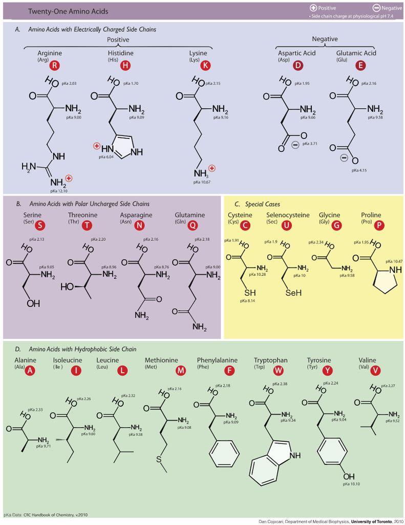

Sin embargo, aún no es tan facil distinguir cuales son los aminoácidos mas frecuentes. Para ello podriamos hacer una gráfica de barras que permitiría identificar rapidamente los aminoácidos más frecuentes y menos frecuentes. Para ello usaremos la función nativa de R: **barplot()** sobre el objeto **p1** que creamos previamente.

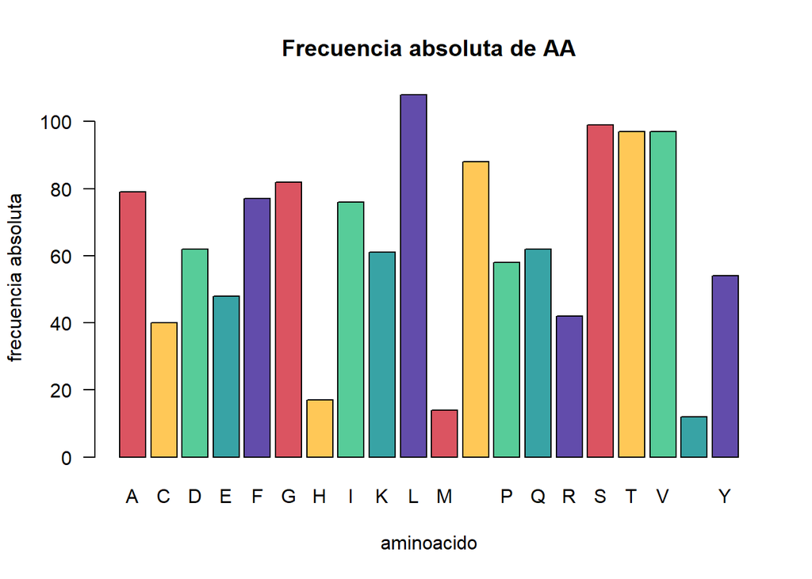

```r
barplot(p1, las = 1, main = "Frecuencia absoluta de AA", ylab = "frecuencia absoluta", xlab = "aminoacido", col = colores1)
```

Tal vez sería mas conveniente verlos ordenados de mayor a menor por su frecuencia relativa. Para ello tendremos que dividir los valores previos entre el número total de aminoácidos de la secuencia. Para ello usaremos la función **length()**.

```r
long <- length(unlist(seqinr::getSequence(spike)))
long
```

```
## [1] 1273
```

Vemos que la longitud de la secuencia es de 1273 aminoácidos. Si dividmos el objeto **p1** entre la longitud **long**, y lo ordenamos con la función **sort()**, podremos ver un gráfico mas util.

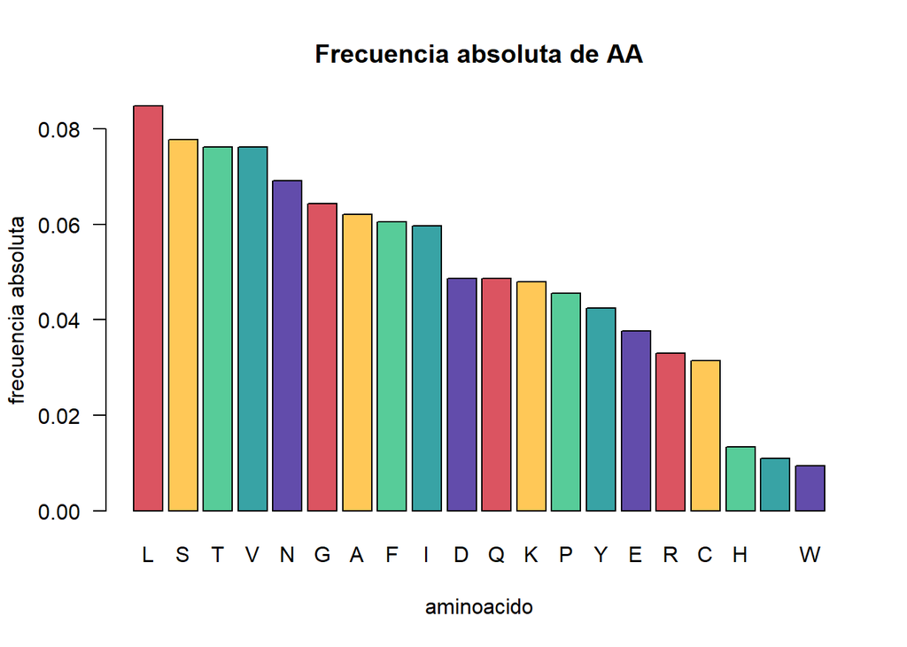

```r
barplot(sort(p1/long, decreasing = T), las = 1, main = "Frecuencia absoluta de AA", ylab = "frecuencia absoluta", xlab = "aminoacido", col = colores1)
```

# Estadística descriptiva de proteínas

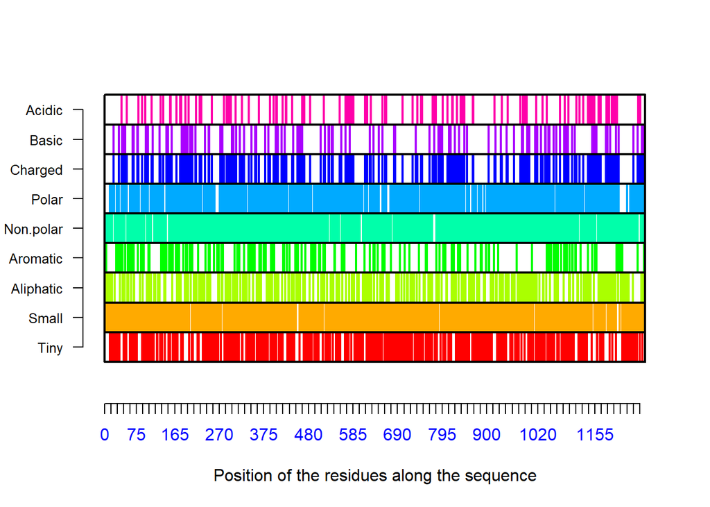

```
## $Compo
##
##   *   A   C   D   E   F   G   H   I   K   L   M   N   P   Q   R   S   T   V   W
##   0  79  40  62  48  77  82  17  76  61 108  14  88  58  62  42  99  97  97  12
##   Y
##  54
##
## $Prop
## $Prop$Tiny
## [1] 0.3118617
##
## $Prop$Small
## [1] 0.5514533
##
## $Prop$Aliphatic
## [1] 0.2207384
##
## $Prop$Aromatic
## [1] 0.1256874
##
## $Prop$Non.polar
## [1] 0.5475255
##
## $Prop$Polar
## [1] 0.4524745
##
## $Prop$Charged
## [1] 0.1806756
##
## $Prop$Basic
## [1] 0.09426551
##
## $Prop$Acidic
## [1] 0.08641005
##
##
## $Pi
## [1] 6.236478
```

```r
secuencia <- seqinr::getSequence(spike)
seqinr::AAstat(unlist(secuencia))
```

A continuanción les muestro una referencia rápida de los terminos usados en esta función.

## Grupos de aminoácidos

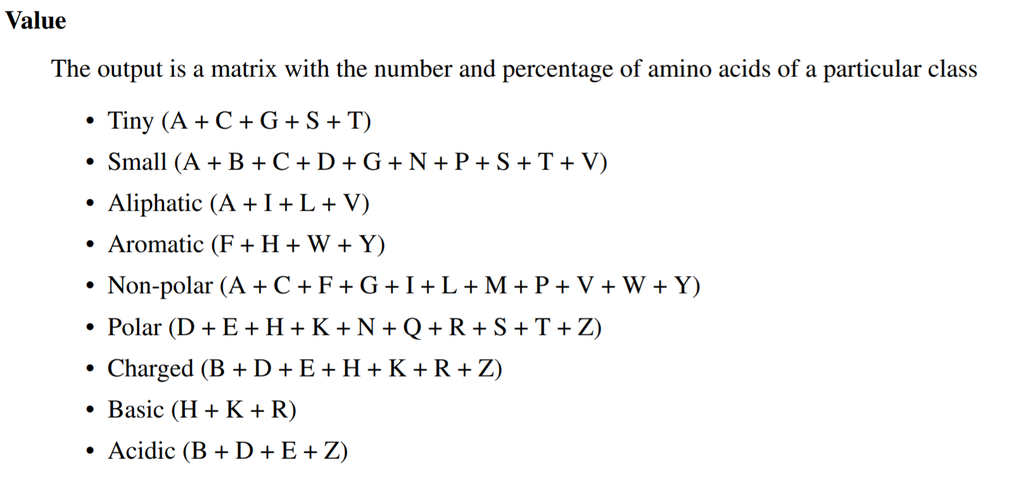